# Flexible Damage Functions

Author

James Rising, Sebastian Cadavid Sanchez, Climate Impact Lab

Published

April 30, 2026

## 0.1 Energy: Non Electricity

Flexible damage function parameters at the Impact Region level.

**Outcome units:** `kWh_per_capita` — kWh per capita, rebased to 2005 baseline (positive = more energy consumed); primarily heating fuels

$$D_{it} = (\alpha_i T_t + \beta_i T_t^2) \cdot Y_{it}^{\gamma}$$

where $\gamma$ is the income elasticity (fitted globally), $\alpha_i$ is the linear coefficient, and $\beta_i$ is the quadratic coefficient.

# 1 Global Estimation

## 1.1 Income Elasticity Estimation

The income elasticity $\gamma$ is estimated using a fixed-effects regression:

$$y_{it} = \gamma \cdot \log(Y_{it}) + \mu_{g(i,T)} + \nu_t + \varepsilon_{it}$$

where $\mu_{g(i,T)}$ are region-by-temperature-bin fixed effects and $\nu_t$ are year fixed effects.

Table 1: Income Elasticity (Gamma) Estimation Results

| Statistic | Value |
| --- | --- |
| Income elasticity ($\gamma$) | -0.2569 |
| Standard error | 1.37e-02 |
| 95% CI | [-0.2837, -0.2300] |
| R-squared | 0.9696 |
| Observations | 16,638,984 |
| Regions | 24,326 |
| Gamma quantiles | 19 |

# 2 Parameter Distributions

## 2.1 8-Panel Summary

Row 1: gamma, alpha, beta, rsqr1. Row 2: rho, zeta, eta, rsqr2.

```
Using median gamma: -0.256872, 24,326 rows (of 462,194 total)
```

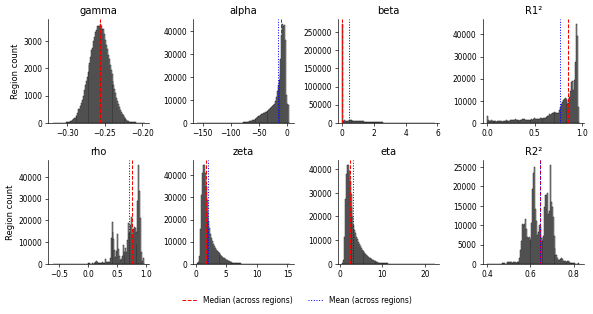

Figure 1: Distribution of Regional Parameters

## 2.2 Projection Equation and Parameter Definitions

The estimated parameters are used to project damages via Monte Carlo sampling:

$$D_{it}^k = (\hat{\alpha}_{ik} T_t + \hat{\beta}_{ik} T_t^2) Y_{it}^{\hat{\gamma}_k} + \hat{\theta}_{ik} T_t Y_{it}^{\hat{\gamma}_k} + \hat{\phi}_{it}^k$$

where $k$ indexes the Monte Carlo draw. The parameters in each row of the output CSV control distinct components of this equation:

- **gamma**: income elasticity $\hat{\gamma}_k$, one of 19 quantile values drawn from $N(\hat{\gamma}, SE(\hat{\gamma}))$
- **alpha, beta**: linear and quadratic temperature coefficients; $\hat{\alpha}_{ik}$ and $\hat{\beta}_{ik}$ are drawn from the joint normal defined by the VCV below
- **sigma11, sigma12, sigma22**: variance-covariance matrix of $(\alpha, \beta)$, used for joint uncertainty sampling
- **rho**: correlation between regional and global polynomial residuals $\rho_i$, used to maintain spatial covariance across regions in Monte Carlo draws
- **zeta**: temperature-dependent error scale $\zeta_{ik}$; the run-specific error term $\hat{\theta}_{ik}$ is drawn from $N(0, \zeta_{ik})$
- **eta**: residual noise standard deviation $\eta_{ik}$; the annual noise $\hat{\phi}_{it}^k$ is drawn from $N(0, \eta_{ik})$
- **rsqr1, rsqr2**: polynomial fit quality and error model fit, respectively

## 2.3 Summary Statistics

Table 2: Regional Parameter Summary

| Parameter | Mean | Median | Std | Min | Max | N |
| --- | --- | --- | --- | --- | --- | --- |
| alpha | -15.73 | -9.965 | 15.15 | -123.9 | 3.796 | 24,326 |
| beta | 0.4472 | 0 | 0.7071 | 0 | 4.639 | 24,326 |
| rho | 0.7035 | 0.7519 | 0.1885 | -0.6103 | 0.981 | 24,326 |
| zeta | 2.027 | 1.676 | 1.117 | 0.3547 | 11.78 | 24,326 |
| eta | 2.994 | 2.424 | 1.705 | 0.6868 | 17.09 | 24,326 |
| rsqr1 | 0.7652 | 0.8498 | 0.224 | 8.012e-08 | 0.9715 | 24,326 |
| rsqr2 | 0.6439 | 0.6433 | 0.05095 | 0.405 | 0.8242 | 24,326 |

# 3 Spaghetti Curves

Regional damage function curves showing D(T) = αT + βT² for sampled regions.

[interactive chart not shown]

Figure 2: Regional Damage Functions

# 4 Zero Crossings

The zero crossing (extremum) of the parabola occurs at $T^* = -\alpha / (2\beta)$.

Table 3: Zero Crossing Statistics

| Category | Count | Percentage |
| --- | --- | --- |
| β = 0 (no crossing) | 14020 | 57.6% |
| T > 20°C (beyond graph) | 2602 | 10.7% |
| T < 0°C (negative crossing) | 0 | 0.0% |
| Valid crossings (0-20°C) | 7704 | 31.7% |

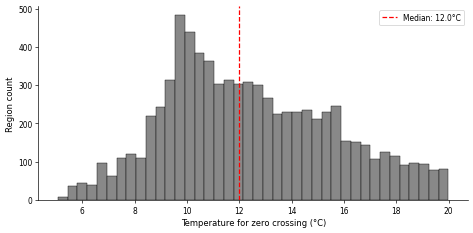

Figure 3: Distribution of Zero Crossing Temperatures

# 5 Slope Analysis

Maximum slope between 0 and 10°C: $\frac{dM}{dT} = \alpha + 2\beta T$

The maximum occurs at either T=0 or T=10 (endpoints of interval).

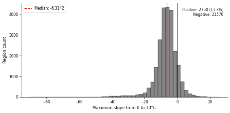

Figure 4: Distribution of Maximum Slopes (0-10°C)

*Convexity analysis omitted (beta constraint active).*

# 6 R-squared Analysis

## 6.1 Polynomial Fit Quality (rsqr1)

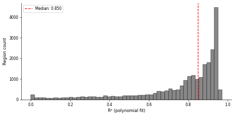

Figure 5: Regional Fit Quality (R-squared)

## 6.2 Error Model R-squared (rsqr2) Quantiles

Table 4: rsqr2 Quantiles

| 0% (Min) | 25% | 50% (Median) | 75% | 100% (Max) |
| --- | --- | --- | --- | --- |
| 0.4050 | 0.6107 | 0.6433 | 0.6851 | 0.8242 |

# 7 Modelled Variance

Modelled variance statistic: $1 - \frac{\sum_i \eta_i^2}{\sum_i D_i^2}$

Table 5: Modelled Variance Statistics

| Statistic | Value |
| --- | --- |
| Modelled variance | 0.9966 |
| Sum(η²) | 288739.4500 |
| Sum(D²) at T=3.0°C | 83989109.3770 |
| N regions | 24,326 |

# 8 Best- and Worst-Fitting Regions

The 3 worst- and 3 best-fitting regions by R-squared, with raw simulation data overlaid on the fitted polynomial curve. **Red rows = worst fits**, **green rows = best fits**.

Table 6: Best- and worst-fitting regions

Top 3 best fit (R²) Top 3 worst fit (R²)

| Region | α | β | η | R² |
| --- | --- | --- | --- | --- |
| USA.6.298 | -59.5 | 1.17 | 6.59 | 0.965 |
| USA.6.269 | -59.3 | 1.25 | 6.59 | 0.964 |
| USA.6.282 | -59 | 1.27 | 6.59 | 0.964 |
| YEM.14.Rbf786ff5b742a5b4 | -2.55 | 0.0242 | 2.68 | 0.155 |
| BOL.2.19.57 | -3.43 | 0.0526 | 4.19 | 0.187 |
| BOL.2.20.60 | -3.36 | 0.0467 | 4.06 | 0.193 |

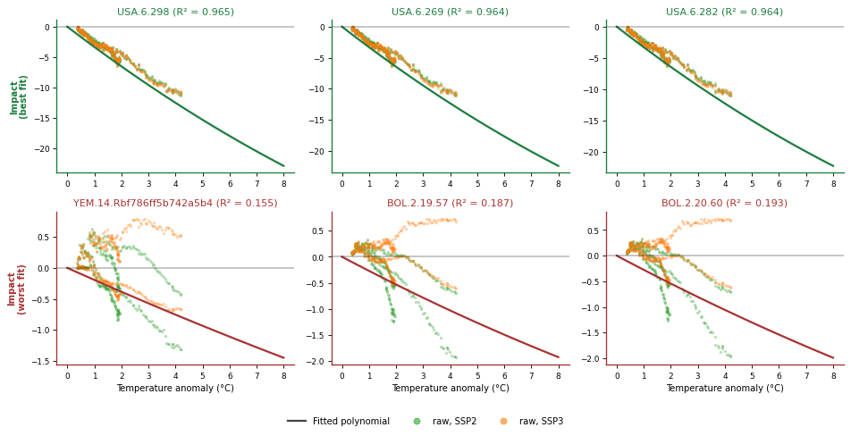

# 9 Regional Parameter Maps

Maps of key parameters at the **impact region** level. Red = negative (damage increases with T), Blue = positive.

## 9.1 Alpha (Linear Coefficient)

Alpha ($\alpha$) represents the linear sensitivity to temperature. Regions with negative alpha experience damage that increases with the first degree of warming.

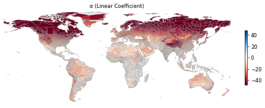

Figure 7: α (linear coefficient)

## 9.2 Beta (Quadratic Coefficient)

Beta ($\beta$) represents the curvature of the damage function.

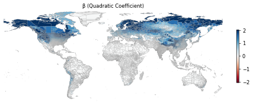

Figure 8: β (quadratic coefficient)

## 9.3 R-squared (Fit Quality)

$R^2$ measures the polynomial fit quality. Higher values indicate that the quadratic form captures more of the variance in the data.

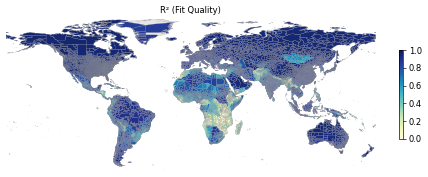

Figure 9: R² (stage 1 fit quality)

# 10 F2: Flex vs Raw Comparison

Comparison of flexible damage function predictions against raw simulation means.

For each scenario (RCP × SSP × Model), we compute at the final year:

- **Flex predicted**: $(\alpha \cdot T + \beta \cdot T^2) \cdot Y^\gamma$
- **Raw actual**: The outcome variable (y) from the source data

**Year 2099**: 195,024 rows

**rcp45**

**SSP2**

**high**

**Correlation:** 0.7996 | **RMSE:** 2.355993 | **Sign agreement:** 22.9%

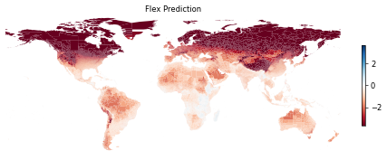

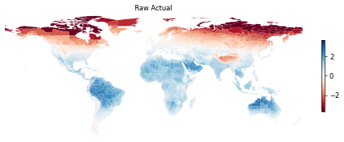

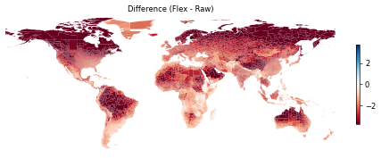

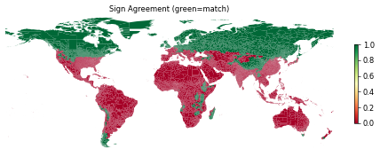

[interactive chart not shown]

Top 5 best predicted Top 5 worst predicted

Year 2099 · T<sub>mean</sub> across these regions: 1.96°C

| Region | Raw | Flex | Residual |
| --- | --- | --- | --- |
| MDG.3.9.39 | 0.297 | 0.297 | -4.40e-4 |
| ETH.8.38.315 | 0.262 | 0.261 | -5.71e-4 |
| MDG.1.1.1 | 0.331 | 0.33 | -0.00167 |
| MMR.12.49.233 | 0.272 | 0.274 | 0.00193 |
| SOM.18.74 | 0.19 | 0.192 | 0.0025 |
| USA.2.84 | -3.9 | -10.7 | -6.82 |
| CAN.6.98.2246 | -4.33 | -10.6 | -6.24 |
| CAN.8.119.2371 | -5.06 | -11.3 | -6.22 |
| CAN.8.119.2375 | -5.37 | -11.5 | -6.16 |
| USA.2.83 | -2.39 | -8.54 | -6.15 |

**low**

**Correlation:** 0.7629 | **RMSE:** 2.339775 | **Sign agreement:** 22.5%

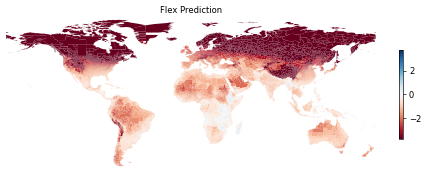

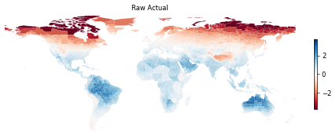

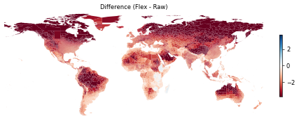

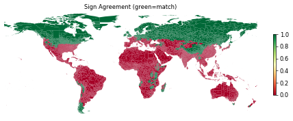

[interactive chart not shown]

Top 5 best predicted Top 5 worst predicted

Year 2099 · T<sub>mean</sub> across these regions: 1.96°C

| Region | Raw | Flex | Residual |
| --- | --- | --- | --- |
| MWI.4 | 0.249 | 0.248 | -9.03e-4 |
| MDG.3.8.36 | 0.165 | 0.166 | 9.47e-4 |
| MMR.12.49.233 | 0.272 | 0.274 | 0.00193 |
| TZA.24.129 | 0.118 | 0.12 | 0.00211 |
| TZA.13.62 | 0.149 | 0.152 | 0.00234 |
| RUS.65.1741.1858 | -5.33 | -12.4 | -7.04 |
| RUS.5.108.108 | -4.85 | -11.7 | -6.84 |
| RUS.14.Rdd2e9902f80893b8 | -2.31 | -8.95 | -6.65 |
| RUS.65.1746.1863 | -3.01 | -9.64 | -6.64 |
| RUS.65.1753.1870 | -4.29 | -10.8 | -6.52 |

**SSP3**

**high**

**Correlation:** 0.7458 | **RMSE:** 2.359421 | **Sign agreement:** 22.6%

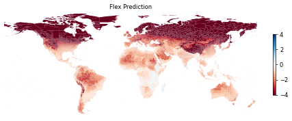

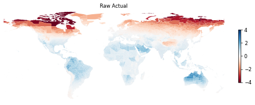

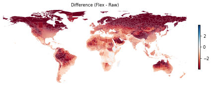

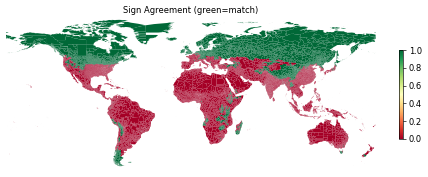

[interactive chart not shown]

Top 5 best predicted Top 5 worst predicted

Year 2099 · T<sub>mean</sub> across these regions: 1.96°C

| Region | Raw | Flex | Residual |
| --- | --- | --- | --- |
| AGO.10.79 | 0.0957 | 0.0952 | -4.65e-4 |
| TZA.1.3 | 0.18 | 0.178 | -0.00213 |
| ETH.8.33.243 | 0.153 | 0.15 | -0.00262 |
| MDG.3.8.36 | 0.163 | 0.161 | -0.00264 |
| KEN.3.14.64.Rfcb48daf05076648 | 0.17 | 0.167 | -0.00314 |
| RUS.65.1741.1858 | -4.73 | -13.1 | -8.34 |
| RUS.5.108.108 | -4.3 | -12.4 | -8.05 |
| RUS.65.1753.1870 | -3.81 | -11.4 | -7.61 |
| RUS.65.1727.1844 | -3.76 | -11.3 | -7.56 |
| RUS.65.1746.1863 | -2.67 | -10.2 | -7.52 |

**low**

**Correlation:** 0.7302 | **RMSE:** 2.402158 | **Sign agreement:** 23.1%

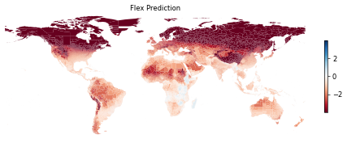

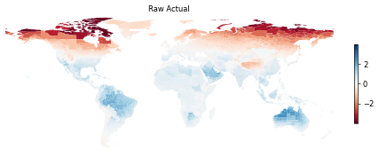

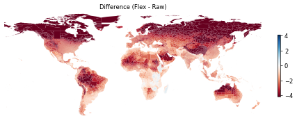

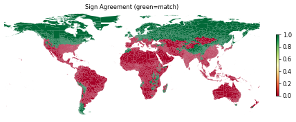

[interactive chart not shown]

Top 5 best predicted Top 5 worst predicted

Year 2099 · T<sub>mean</sub> across these regions: 1.96°C

| Region | Raw | Flex | Residual |
| --- | --- | --- | --- |
| ETH.1.4.19 | -0.132 | -0.132 | -4.14e-4 |
| AGO.10.79 | 0.0957 | 0.0952 | -4.65e-4 |
| ETH.3.17.Rbd4574dd09453ddb | -0.133 | -0.129 | 0.00359 |
| MMR.12.52.247 | 0.142 | 0.136 | -0.00512 |
| NPL.1.1.8 | -0.0981 | -0.092 | 0.00612 |
| RUS.65.1741.1858 | -4.74 | -12.9 | -8.19 |
| RUS.5.108.108 | -4.31 | -12.2 | -7.91 |
| CAN.8.117.2359 | -5.15 | -13 | -7.89 |
| CAN.8.119.2375 | -4.61 | -12.4 | -7.82 |
| CAN.8.119.2371 | -4.34 | -12.2 | -7.82 |

**rcp85**

**SSP2**

**high**

**Correlation:** 0.7681 | **RMSE:** 5.267518 | **Sign agreement:** 17.0%

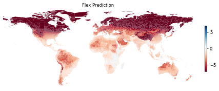

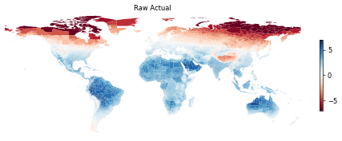

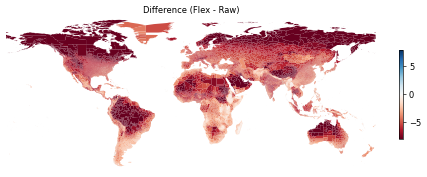

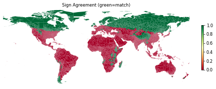

[interactive chart not shown]

Top 5 best predicted Top 5 worst predicted

Year 2099 · T<sub>mean</sub> across these regions: 4.20°C

| Region | Raw | Flex | Residual |
| --- | --- | --- | --- |
| MMR.12.48.231 | 0.588 | 0.614 | 0.0261 |
| MMR.3.10.58 | 0.584 | 0.631 | 0.0474 |
| SOM.18.74 | 0.465 | 0.413 | -0.0516 |
| ERI.2.11 | 0.759 | 0.687 | -0.0725 |
| MMR.12.47.221 | 0.724 | 0.645 | -0.0788 |
| CAN.8.117.2359 | -11.2 | -25.1 | -13.9 |
| USA.2.84 | -7.54 | -20.7 | -13.2 |
| CAN.8.119.2375 | -10.2 | -23.4 | -13.1 |
| CAN.8.119.2371 | -9.73 | -22.7 | -13 |
| QAT.5 | 7.42 | -5.48 | -12.9 |

**low**

**Correlation:** 0.7117 | **RMSE:** 5.163200 | **Sign agreement:** 16.9%

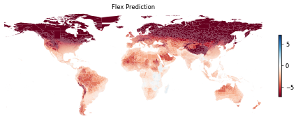

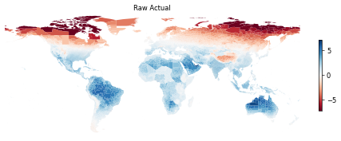

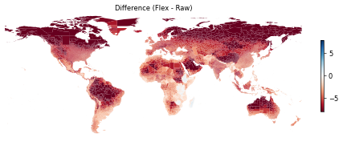

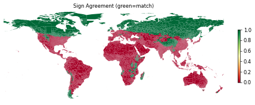

[interactive chart not shown]

Top 5 best predicted Top 5 worst predicted